# CropStress Intelligence: Dataset Validation and Initial RNA-seq Quality Assessment

CropStress Intelligence Project

14 November 2026

# 1 Project overview

CropStress Intelligence investigates rice (*Oryza sativa*) gene-expression patterns associated with drought stress and subsequent recovery.

This report documents dataset preparation, validation, and initial sample-level RNA-seq quality assessment using the locally stored GEO count matrix and integrated sample annotations.

## 1.1 Dataset information

| Attribute | Description |
| --- | --- |
| GEO accession | GSE288615 |
| Organism | *Oryza sativa* |
| Cultivar | IR64 |
| Data type | RNA-seq raw gene-expression counts |
| Expected samples | 72 |
| Expected expression records | 55,986 |
| Reference genome reported in project metadata | IRGSP-1.0 |

The dataset metadata describes an experiment involving drought treatment and subsequent rehydration, with multiple collection time points and leaf positions.

# 2 1. Set project paths

Open `CropStress_Intelligence.Rproj` in RStudio. This report is intended to be stored in `reports/` and knitted from the project.

```r
counts_file <- file.path(
  "data", "raw",
  "GSE288615_rawCounts_IR64_rehydration_All_samples.txt"
)

metadata_file <- file.path(
  "results", "tables",
  "integrated_sample_metadata.csv"
)

figures_dir <- file.path("results", "figures")
tables_dir  <- file.path("results", "tables")

if (!dir.exists(figures_dir)) {
  dir.create(figures_dir, recursive = TRUE)
}

if (!dir.exists(tables_dir)) {
  dir.create(tables_dir, recursive = TRUE)
}

stopifnot(file.exists(counts_file))
stopifnot(file.exists(metadata_file))

cat("Count matrix:", counts_file, "\n")
```

```
## Count matrix: data/raw/GSE288615_rawCounts_IR64_rehydration_All_samples.txt
```

```r
cat("Sample metadata:", metadata_file, "\n")
```

```
## Sample metadata: results/tables/integrated_sample_metadata.csv
```

# 3 2. Import the count matrix and sample metadata

The count matrix is read without changing sample column names so that library identifiers can be matched exactly with the metadata.

```r
counts <- read.delim(
  counts_file,
  header = TRUE,
  check.names = FALSE
)

sample_metadata <- read.csv(
  metadata_file,
  stringsAsFactors = FALSE,
  check.names = FALSE
)

cat("Count matrix dimensions:\n")
```

```
## Count matrix dimensions:
```

```r
print(dim(counts))
```

```
## [1] 55986    72
```

```r
cat("\nSample metadata dimensions:\n")
```

```
##
## Sample metadata dimensions:
```

```r
print(dim(sample_metadata))
```

```
## [1] 72  8
```

```r
cat("\nFirst six count-matrix rows:\n")
```

```
##
## First six count-matrix rows:
```

```r
head(counts)
```

```
##   IR0C1L1 IR0C1L2 IR0C2L1 IR0C2L2 IR0C3L1 IR0C3L2 IR0D1L1 IR0D1L2 IR0D2L1
## 1     845     682     860     614     661     751    1103     418     720
## 2       3       0       0       0       0       2       7       1       0
## 3      50      49      36      48      22      38      59      33      50
## 4     484     469     563     507     399     553     722     353     504
## 5     641     616     575     563     492     674     753     429     586
## 6     356     451     300     400     374     543     266     154     292
##   IR0D2L2 IR0D3L1 IR0D3L2 IR12C1L1 IR12C1L2 IR12C2L1 IR12C2L2 IR12C3L1 IR12C3L2
## 1     519    1214     749      706      826      961      723      867     1318
## 2       4       4       8        1        2        1        4        3        7
## 3      28      76      46       36       49       53       45       41       61
## 4     404     735     532      549      682      644      508      557     1090
## 5     542     789     589      691      846      922      763      622     1154
## 6     257     184     248      302      511      483      596      196     1035
##   IR12D1L1 IR12D1L2 IR12D2L1 IR12D2L2 IR12D3L1 IR12D3L2 IR15C1L1 IR15C1L2
```

[output cut: 48 more lines]

```r
cat("\nFirst six metadata rows:\n")
```

```
##
## First six metadata rows:
```

```r
head(sample_metadata)
```

```
##   geo_accession library_name cultivar             tissue
## 1    GSM8771207      IR0C1L1     IR64        latest leaf
## 2    GSM8771208      IR0C1L2     IR64 second latest leaf
## 3    GSM8771209      IR0C2L1     IR64        latest leaf
## 4    GSM8771210      IR0C2L2     IR64 second latest leaf
## 5    GSM8771211      IR0C3L1     IR64        latest leaf
## 6    GSM8771212      IR0C3L2     IR64 second latest leaf
##                  treatment day replicate
## 1 control (severe drought)   0         1
## 2 control (severe drought)   0         1
## 3 control (severe drought)   0         2
## 4 control (severe drought)   0         2
## 5 control (severe drought)   0         3
## 6 control (severe drought)   0         3
##                                                              title
## 1        IR64, latest leaf, control (severe drought), Day 0, rep 1
## 2 IR64, second latest leaf, control (severe drought), Day 0, rep 1
## 3        IR64, latest leaf, control (severe drought), Day 0, rep 2
## 4 IR64, second latest leaf, control (severe drought), Day 0, rep 2
## 5        IR64, latest leaf, control (severe drought), Day 0, rep 3
## 6 IR64, second latest leaf, control (severe drought), Day 0, rep 3
```

# 4 3. Validate the imported data

## 4.1 3.1 Check count-column types

The expression columns are expected to contain numeric raw counts. The first column may contain feature identifiers and is not included in the numeric count matrix.

```r
stopifnot("library_name" %in% names(sample_metadata))

sample_ids_from_metadata <- sample_metadata$library_name

count_columns <- setdiff(
  names(counts),
  names(counts)[1]
)

# Identify sample columns by matching metadata library names.
missing_count_columns <- setdiff(
  sample_ids_from_metadata,
  names(counts)
)

cat("Metadata samples missing from count matrix:\n")
```

```
## Metadata samples missing from count matrix:
```

```r
print(missing_count_columns)
```

```
## character(0)
```

```r
stopifnot(length(missing_count_columns) == 0)

count_matrix <- as.matrix(
  counts[, sample_ids_from_metadata, drop = FALSE]
)

storage.mode(count_matrix) <- "numeric"

cat("All count-matrix values numeric:",
    is.numeric(count_matrix), "\n")
```

```
## All count-matrix values numeric: TRUE
```

## 4.2 3.2 Check missing and negative values

```r
total_missing <- sum(is.na(count_matrix))
total_negative <- sum(count_matrix < 0, na.rm = TRUE)

cat("Missing count values:", total_missing, "\n")
```

```
## Missing count values: 0
```

```r
cat("Negative count values:", total_negative, "\n")
```

```
## Negative count values: 0
```

```r
stopifnot(total_missing == 0)
stopifnot(total_negative == 0)
```

## 4.3 3.3 Check sample identifiers and ordering

```r
metadata_sample_ids <- sample_metadata$library_name
count_sample_ids <- colnames(count_matrix)

cat("Samples in count matrix:", length(count_sample_ids), "\n")
```

```
## Samples in count matrix: 72
```

```r
cat("Samples in metadata:", length(metadata_sample_ids), "\n")
```

```
## Samples in metadata: 72
```

```r
cat(
  "Both sources contain the same sample identifiers:",
  setequal(metadata_sample_ids, count_sample_ids),
  "\n"
)
```

```
## Both sources contain the same sample identifiers: TRUE
```

```r
cat(
  "Sample order is identical:",
  identical(metadata_sample_ids, count_sample_ids),
  "\n"
)
```

```
## Sample order is identical: TRUE
```

```r
stopifnot(setequal(metadata_sample_ids, count_sample_ids))

sample_metadata <- sample_metadata[
  match(count_sample_ids, sample_metadata$library_name),
  ,
  drop = FALSE
]

stopifnot(
  identical(sample_metadata$library_name, count_sample_ids)
)
```

# 5 4. Review the experimental design

```r
cat("Metadata columns:\n")
```

```
## Metadata columns:
```

```r
print(names(sample_metadata))
```

```
## [1] "geo_accession" "library_name"  "cultivar"      "tissue"
## [5] "treatment"     "day"           "replicate"     "title"
```

```r
for (field in intersect(
  c("cultivar", "tissue", "treatment", "day", "replicate"),
  names(sample_metadata)
)) {
  cat("\n", field, ":\n", sep = "")
  print(unique(sample_metadata[[field]]))
}
```

```
##
## cultivar:
## [1] "IR64"
##
## tissue:
## [1] "latest leaf"        "second latest leaf"
##
## treatment:
## [1] "control (severe drought)"         "severe drought"
## [3] "control (rehydration)"            "rehydration after severe drought"
##
## day:
## [1] "0"      "3"      "6"      "9"      "0 (2h)"
##
## replicate:
## [1] 1 2 3
```

## 5.1 4.1 Sample counts by treatment

```r
if ("treatment" %in% names(sample_metadata)) {
  print(table(sample_metadata$treatment))
}
```

```
##
##            control (rehydration)         control (severe drought)
##                               18                               18
## rehydration after severe drought                   severe drought
##                               18                               18
```

## 5.2 4.2 Sample counts by treatment, time point and tissue

```r
required_design_fields <- c("treatment", "day", "tissue")

if (all(required_design_fields %in% names(sample_metadata))) {
  group_distribution <- xtabs(
    ~ treatment + day + tissue,
    data = sample_metadata
  )

  print(group_distribution)
}
```

```
## , , tissue = latest leaf
##
##                                   day
## treatment                          0 0 (2h) 3 6 9
##   control (rehydration)            0      3 3 3 0
##   control (severe drought)         3      0 0 3 3
##   rehydration after severe drought 0      3 3 3 0
##   severe drought                   3      0 0 3 3
##
## , , tissue = second latest leaf
##
##                                   day
## treatment                          0 0 (2h) 3 6 9
##   control (rehydration)            0      3 3 3 0
##   control (severe drought)         3      0 0 3 3
##   rehydration after severe drought 0      3 3 3 0
##   severe drought                   3      0 0 3 3
```

# 6 5. Calculate sample-level quality metrics

Library size is the sum of raw counts across expression records for a sample. Detected records are rows with a count greater than zero. These are descriptive metrics and do not independently establish whether a sample is biologically or technically valid.

```r
library_sizes <- colSums(count_matrix)
detected_records <- colSums(count_matrix > 0)

sample_qc <- data.frame(
  library_name = names(library_sizes),
  library_size = as.numeric(library_sizes),
  detected_records = as.numeric(detected_records),
  stringsAsFactors = FALSE
)

sample_qc <- merge(
  sample_metadata,
  sample_qc,
  by = "library_name",
  sort = FALSE
)

sample_qc <- sample_qc[
  match(count_sample_ids, sample_qc$library_name),
  ,
  drop = FALSE
]

stopifnot(identical(sample_qc$library_name, count_sample_ids))

head(sample_qc)
```

```
##   library_name geo_accession cultivar             tissue
## 1      IR0C1L1    GSM8771207     IR64        latest leaf
## 2      IR0C1L2    GSM8771208     IR64 second latest leaf
## 3      IR0C2L1    GSM8771209     IR64        latest leaf
## 4      IR0C2L2    GSM8771210     IR64 second latest leaf
## 5      IR0C3L1    GSM8771211     IR64        latest leaf
## 6      IR0C3L2    GSM8771212     IR64 second latest leaf
##                  treatment day replicate
## 1 control (severe drought)   0         1
## 2 control (severe drought)   0         1
## 3 control (severe drought)   0         2
## 4 control (severe drought)   0         2
## 5 control (severe drought)   0         3
## 6 control (severe drought)   0         3
##                                                              title library_size
## 1        IR64, latest leaf, control (severe drought), Day 0, rep 1     14779426
## 2 IR64, second latest leaf, control (severe drought), Day 0, rep 1     11915536
## 3        IR64, latest leaf, control (severe drought), Day 0, rep 2     14966617
## 4 IR64, second latest leaf, control (severe drought), Day 0, rep 2     11230086
## 5        IR64, latest leaf, control (severe drought), Day 0, rep 3     10680942
## 6 IR64, second latest leaf, control (severe drought), Day 0, rep 3     11892303
##   detected_records
## 1            25647
## 2            25744
## 3            26197
## 4            25582
## 5            25051
## 6            25952
```

## 6.1 5.1 Summary statistics

```r
summary(sample_qc$library_size)
```

```
##     Min.  1st Qu.   Median     Mean  3rd Qu.     Max.
##     1755 11974692 13707163 14163804 16454666 24192248
```

```r
summary(sample_qc$detected_records)
```

```
##    Min. 1st Qu.  Median    Mean 3rd Qu.    Max.
##    1046   25770   26187   25932   26793   28607
```

# 7 6. Visualise sample quality metrics

## 7.1 6.1 Library-size distribution

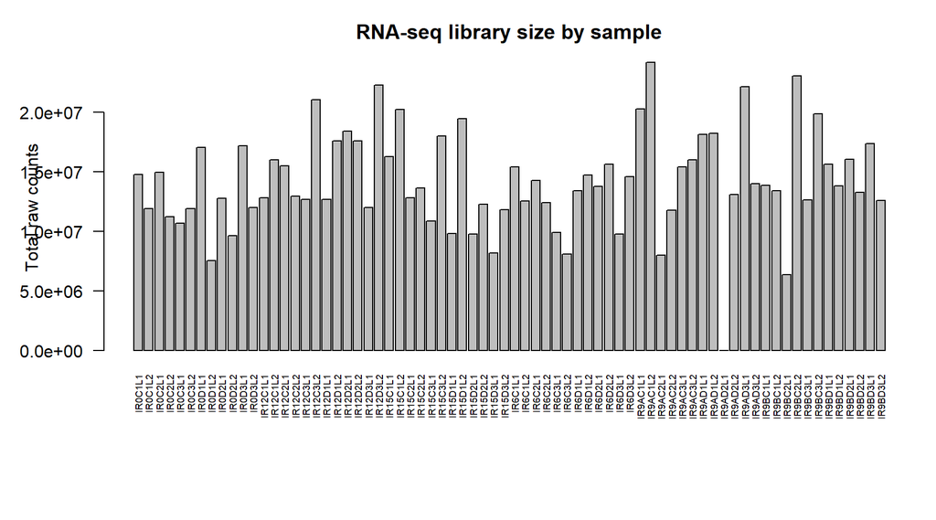

Total raw counts (library size) for each sample.

```r
old_par <- par(no.readonly = TRUE)
par(mar = c(8, 5, 3, 1))

barplot(
  sample_qc$library_size,
  names.arg = sample_qc$library_name,
  las = 2,
  cex.names = 0.55,
  ylab = "Total raw counts",
  main = "RNA-seq library size by sample"
)
```

```r
par(old_par)

png(
  filename = file.path(figures_dir, "library_size_distribution.png"),
  width = 1400,
  height = 800,
  res = 130
)

par(mar = c(8, 5, 3, 1))
barplot(
  sample_qc$library_size,
  names.arg = sample_qc$library_name,
  las = 2,
  cex.names = 0.55,
  ylab = "Total raw counts",
  main = "RNA-seq library size by sample"
)
dev.off()
```

## 7.2 6.2 Detected expression records per sample

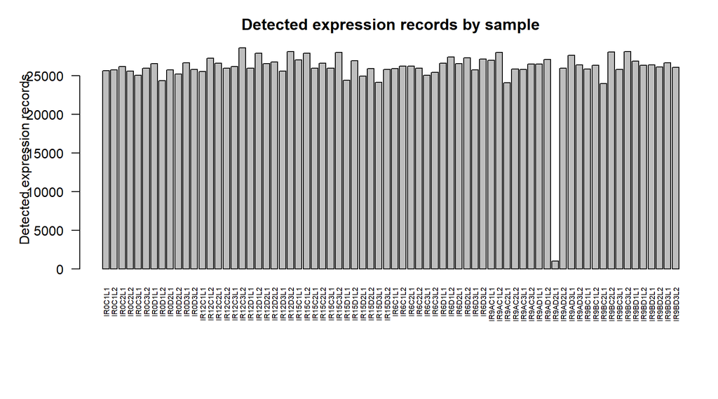

Number of expression records with non-zero counts in each sample.

```r
old_par <- par(no.readonly = TRUE)
par(mar = c(8, 5, 3, 1))

barplot(
  sample_qc$detected_records,
  names.arg = sample_qc$library_name,
  las = 2,
  cex.names = 0.55,
  ylab = "Detected expression records",
  main = "Detected expression records by sample"
)
```

```r
par(old_par)

png(
  filename = file.path(figures_dir, "detected_records_by_sample.png"),
  width = 1400,
  height = 800,
  res = 130
)

par(mar = c(8, 5, 3, 1))
barplot(
  sample_qc$detected_records,
  names.arg = sample_qc$library_name,
  las = 2,
  cex.names = 0.55,
  ylab = "Detected expression records",
  main = "Detected expression records by sample"
)
dev.off()
```

# 8 7. Investigate the flagged sample

The sample `IR9AD2L1` was identified during initial quality assessment as having an unusually low library size and few detected expression records. The following code verifies its metrics against the imported count matrix. It does not remove the sample.

```r
flagged_sample <- "IR9AD2L1"

stopifnot(flagged_sample %in% colnames(count_matrix))

flagged_metrics <- sample_qc[
  sample_qc$library_name == flagged_sample,
  c("library_name", "library_size", "detected_records"),
  drop = FALSE
]

print(flagged_metrics)
```

```
##    library_name library_size detected_records
## 57     IR9AD2L1         1755             1046
```

## 8.1 7.1 Relative library size

The relative library size is calculated as the target sample’s library size divided by the median library size across all samples, multiplied by 100.

```r
median_library_size <- median(sample_qc$library_size)

target_library_size <- sample_qc$library_size[
  sample_qc$library_name == flagged_sample
]

relative_library_size <- (
  target_library_size / median_library_size
) * 100

fold_difference <- median_library_size / target_library_size

cat("Target sample library size:", target_library_size, "\n")
```

```
## Target sample library size: 1755
```

```r
cat("Median library size:", median_library_size, "\n")
```

```
## Median library size: 13707163
```

```r
cat(
  "Target sample relative to median (%):",
  round(relative_library_size, 4),
  "%\n"
)
```

```
## Target sample relative to median (%): 0.0128 %
```

```r
cat(
  "Median library size is",
  round(fold_difference, 2),
  "times larger than target sample.\n"
)
```

```
## Median library size is 7810.35 times larger than target sample.
```

## 8.2 7.2 Count distribution of the flagged sample

```r
target_counts <- count_matrix[, flagged_sample]

zero_counts <- sum(target_counts == 0)
nonzero_counts <- sum(target_counts > 0)
total_records <- length(target_counts)

target_count_summary <- data.frame(
  library_name = flagged_sample,
  total_records = total_records,
  total_counts = sum(target_counts),
  zero_records = zero_counts,
  nonzero_records = nonzero_counts,
  zero_percentage = (zero_counts / total_records) * 100,
  nonzero_percentage = (nonzero_counts / total_records) * 100,
  maximum_count = max(target_counts),
  mean_count = mean(target_counts)
)

print(summary(target_counts))
```

```
##     Min.  1st Qu.   Median     Mean  3rd Qu.     Max.
##  0.00000  0.00000  0.00000  0.03135  0.00000 19.00000
```

```r
print(target_count_summary)
```

```
##   library_name total_records total_counts zero_records nonzero_records
## 1     IR9AD2L1         55986         1755        54940            1046
##   zero_percentage nonzero_percentage maximum_count mean_count
## 1        98.13168           1.868324            19 0.03134712
```

```r
cat("\nTop 10 counts:\n")
```

```
##
## Top 10 counts:
```

```r
print(head(sort(target_counts, decreasing = TRUE), 10))
```

```
##  [1] 19 19 19 19 17 17 16 16 15 15
```

# 9 8. Compare biological replicates

The flagged sample belongs to the following experimental group, according to the integrated metadata:

- Cultivar: IR64
- Tissue: latest leaf
- Treatment: severe drought
- Collection day: 9

The comparison below selects samples sharing the same treatment, day and tissue as the flagged sample.

```r
target_metadata <- sample_metadata[
  sample_metadata$library_name == flagged_sample,
  ,
  drop = FALSE
]

stopifnot(nrow(target_metadata) == 1)

same_group <- sample_metadata[
  sample_metadata$treatment == target_metadata$treatment &
    sample_metadata$day == target_metadata$day &
    sample_metadata$tissue == target_metadata$tissue,
  ,
  drop = FALSE
]

cat("Samples in the same experimental group:\n")
```

```
## Samples in the same experimental group:
```

```r
print(same_group)
```

```
##    geo_accession library_name cultivar      tissue      treatment day replicate
## 55    GSM8771261     IR9AD1L1     IR64 latest leaf severe drought   9         1
## 57    GSM8771263     IR9AD2L1     IR64 latest leaf severe drought   9         2
## 59    GSM8771265     IR9AD3L1     IR64 latest leaf severe drought   9         3
##                                              title
## 55 IR64, latest leaf, severe drought, Day 9, rep 1
## 57 IR64, latest leaf, severe drought, Day 9, rep 2
## 59 IR64, latest leaf, severe drought, Day 9, rep 3
```

## 9.1 8.1 Replicate count-distribution metrics

```r
replicate_samples <- same_group$library_name

replicate_distribution <- data.frame(
  library_name = replicate_samples,
  total_counts = NA_real_,
  zero_records = NA_integer_,
  nonzero_records = NA_integer_,
  zero_percentage = NA_real_,
  maximum_count = NA_real_,
  mean_count = NA_real_,
  stringsAsFactors = FALSE
)

for (i in seq_along(replicate_samples)) {
  sample_name <- replicate_samples[i]
  current_counts <- count_matrix[, sample_name]

  replicate_distribution$total_counts[i] <- sum(current_counts)
  replicate_distribution$zero_records[i] <- sum(current_counts == 0)
  replicate_distribution$nonzero_records[i] <- sum(current_counts > 0)
  replicate_distribution$zero_percentage[i] <-
    mean(current_counts == 0) * 100
  replicate_distribution$maximum_count[i] <- max(current_counts)
  replicate_distribution$mean_count[i] <- mean(current_counts)
}

print(replicate_distribution)
```

```
##   library_name total_counts zero_records nonzero_records zero_percentage
## 1     IR9AD1L1     18122395        29482           26504        52.65959
## 2     IR9AD2L1         1755        54940            1046        98.13168
## 3     IR9AD3L1     22131076        28387           27599        50.70375
##   maximum_count   mean_count
## 1        291823 323.69512021
## 2            19   0.03134712
## 3        319012 395.29660987
```

## 9.2 8.2 Visualise biological replicate library sizes

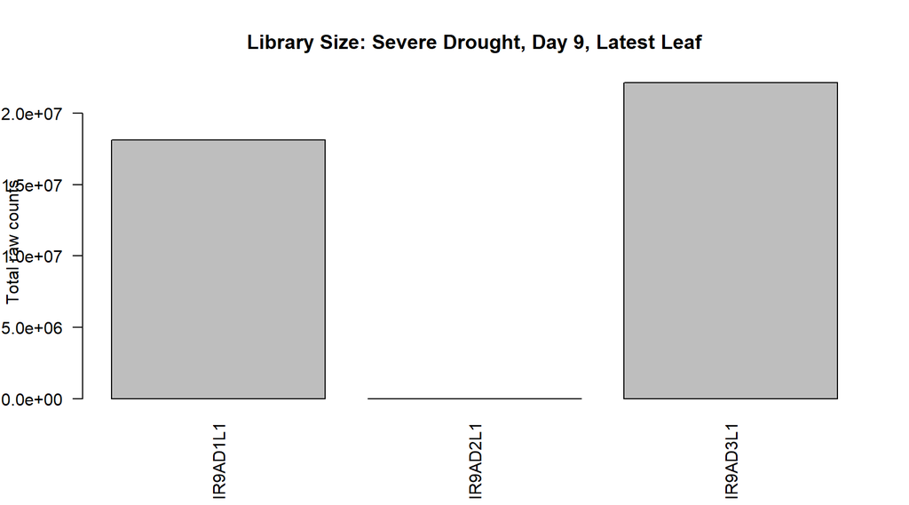

Library-size comparison among biological replicates from severe drought, Day 9, latest leaf.

```r
barplot(
  height = replicate_distribution$total_counts,
  names.arg = replicate_distribution$library_name,
  las = 2,
  ylab = "Total raw counts",
  main = "Library Size: Severe Drought, Day 9, Latest Leaf"
)
```

```r
png(
  filename = file.path(
    figures_dir,
    "severe_drought_day9_replicates.png"
  ),
  width = 1200,
  height = 800,
  res = 120
)

barplot(
  height = replicate_distribution$total_counts,
  names.arg = replicate_distribution$library_name,
  las = 2,
  ylab = "Total raw counts",
  main = "Library Size: Severe Drought, Day 9, Latest Leaf"
)

dev.off()
```

## 9.3 8.3 Save replicate comparison table

```r
replicate_output_file <- file.path(
  tables_dir,
  "replicate_count_distribution.csv"
)

write.csv(
  replicate_distribution,
  file = replicate_output_file,
  row.names = FALSE
)

cat("Replicate distribution saved:",
    file.exists(replicate_output_file), "\n")
```

```
## Replicate distribution saved: TRUE
```

```r
cat("Output:", replicate_output_file, "\n")
```

```
## Output: results/tables/replicate_count_distribution.csv
```

# 10 9. Save quality-control tables

```r
qc_output_file <- file.path(
  tables_dir,
  "initial_sample_qc_summary.csv"
)

write.csv(
  sample_qc,
  file = qc_output_file,
  row.names = FALSE
)

cat("Initial QC summary saved:",
    file.exists(qc_output_file), "\n")
```

```
## Initial QC summary saved: TRUE
```

```r
cat("Output:", qc_output_file, "\n")
```

```
## Output: results/tables/initial_sample_qc_summary.csv
```

```r
cat("\nQC summary dimensions:\n")
```

```
##
## QC summary dimensions:
```

```r
print(dim(sample_qc))
```

```
## [1] 72 10
```

# 11 10. Findings and scientific interpretation

The analysis identified `IR9AD2L1` as an extreme sample-level count anomaly in the current count matrix.

The observed values from the current analysis are:

| Metric | IR9AD2L1 |
| --- | --- |
| Library size | 1,755 |
| Detected expression records | 1,046 |
| Zero-count records | 54,940 |
| Total expression records | 55,986 |
| Zero-count percentage | 98.13% |
| Non-zero percentage | 1.87% |
| Maximum count | 19 |

The sample belongs to the severe drought, Day 9, latest-leaf group. Its two other biological replicates have substantially larger library sizes in the current count matrix.

These observations support flagging `IR9AD2L1` for further investigation. They do not establish the cause of the anomaly. The count matrix alone cannot confirm sequencing failure, RNA degradation, library-preparation failure, or sample-mapping error.

**No sample is excluded in this report.** Any exclusion decision must be supported by further evidence, documented rationale, and consideration of the effect on downstream analysis.

The term “detected expression records” refers to rows with non-zero counts. These rows should not be described as uniquely identified genes until the count-matrix feature identifiers have been validated.

# 12 11. Limitations and next analysis steps

The next stages should include:

- Inspect count-matrix row identifiers and establish whether they represent genes, transcripts, or another feature type.
- Investigate the flagged sample using original study documentation and sequencing-quality information, if available.
- Examine sample relationships using suitable exploratory analyses, such as PCA and sample-distance clustering, after selecting an appropriate transformation.
- Determine filtering and normalization methods based on the dataset structure and intended differential-expression analysis.
- Preserve the raw count matrix and document every preprocessing decision.

Differential expression analysis is not performed in this report.

# 13 12. Reproducibility information

```r
cat("R version:\n")
```

```
## R version:
```

```r
print(R.version.string)
```

```
## [1] "R version 4.6.2 (2026-10-29 ucrt)"
```

```r
cat("\nSession information:\n")
```

```
##
## Session information:
```